# Practice Problems 6

Solutions

# Part 0. Load Packages

Use the code chunk below to load any packages that you need for this assignment. Add `message = FALSE` to the top of your code chunk to hide the messages that print out when you load these packages.

```r
# at minimum, you should have loaded these packages:
library(readr)
library(dplyr)
library(ggplot2)
library(broom)

# depending on your project data, you may have needed others
## e.g., library(NHANES)
## e.g., library(ggmosaic)
```

> Make sure you added `message = FALSE` to the start of your code chunk.

# Part 1. FEV Data

Answer the following questions about the `fev.csv` dataset.

## Load Data in R

Enter code in the code chunk below to load the `fev.csv` dataset into R. Make sure that you’ve downloaded the `.csv` file from Moodle and it’s saved in the same folder as this RMD. Add `message = FALSE` to the top of your code chunk to hide the messages that print out when you read in this data set.

```r
# read in FEV dataset
fevdata <- read_csv('../activities/fev.csv')
```

> I have the `fev.csv` dataset stored in a different folder than this RMD, so my code may look a little different from yours. If your CSV and RMD files are saved in the same folder, then the code will just be `fevdata <- read_csv('fev.csv')`.

> Make sure you added `message = FALSE` to the start of your code chunk.

## Linear Regression - Fit Model

Add code to the code chunk below to fit two models:

- `mod1`: a model of FEV as a function of smoking and age
- `mod2`: a model of FEV as a function of smoking, age, and their interaction

Print out coefficient estimates for each of the models.

```r
# model of FEV versus smoke and age
## fit and save model
mod1 <- lm(fev ~ smoke + age, data = fevdata)

## print out coefficients: option 1
coef(mod1)
```

```
## (Intercept) smokesmoker         age
##   0.3673730  -0.2089949   0.2306046
```

```r
## print out coefficients: option 2
tidy(mod1)
```

```
## # A tibble: 3 × 5
##   term        estimate std.error statistic   p.value
##   <chr>          <dbl>     <dbl>     <dbl>     <dbl>
## 1 (Intercept)    0.367   0.0814       4.51 7.65e-  6
## 2 smokesmoker   -0.209   0.0807      -2.59 9.86e-  3
## 3 age            0.231   0.00818     28.2  8.28e-115
```

```r
# model of FEV versus smoke, age, and their interaction
## fit and save model
mod2 <- lm(fev ~ smoke + age + smoke:age, data = fevdata)

## print out coefficients: option 1
coef(mod2)
```

```
##     (Intercept)     smokesmoker             age smokesmoker:age
##       0.2533955       1.9435707       0.2425584      -0.1627027
```

```r
## print out coefficients: option 2
tidy(mod2)
```

```
## # A tibble: 4 × 5
##   term            estimate std.error statistic   p.value
##   <chr>              <dbl>     <dbl>     <dbl>     <dbl>
## 1 (Intercept)        0.253   0.0827       3.07 2.26e-  3
## 2 smokesmoker        1.94    0.414        4.69 3.31e-  6
## 3 age                0.243   0.00833     29.1  6.50e-120
## 4 smokesmoker:age   -0.163   0.0307      -5.29 1.65e-  7
```

> I recommend writing your code in such a way that you fit your linear regression models and *save* them as an object. Give each model its own name (e.g., `mod1`, `mod2`) so you can keep them separate from one another. Saving our models will make it easier for us to work with them (e.g., creating residual plots, calculating model quality metrics) later.

> In the code above, I demonstrate two different ways of printing out coefficient estimates. Using the `coef` function prints out the estimates only, and using the `tidy` function prints out the estimates as well as some other information (standard error, test statistic, and p-value). We’ll talk about how to interpret these other pieces of information soon!

> Finally, note that there is more than one way to write code for an interaction model. Here’s an equally correct way to fit this model:

```r
mod2option2 <- lm(fev ~ smoke * age, data = fevdata)
tidy(mod2option2)
```

```
## # A tibble: 4 × 5
##   term            estimate std.error statistic   p.value
##   <chr>              <dbl>     <dbl>     <dbl>     <dbl>
## 1 (Intercept)        0.253   0.0827       3.07 2.26e-  3
## 2 smokesmoker        1.94    0.414        4.69 3.31e-  6
## 3 age                0.243   0.00833     29.1  6.50e-120
## 4 smokesmoker:age   -0.163   0.0307      -5.29 1.65e-  7
```

## Linear Regression - Evaluation - Residual Plots

Make three residual plots for `mod1`:

- plot the residuals against the fitted values
- plot the residuals against one explanatory variable (smoking)
- plot the residuals against the other explanatory variable (age)

> Notice that I added `message = F` to the start of my code chunk here to hide the messages that otherwise print out about the `geom_smooth` function.

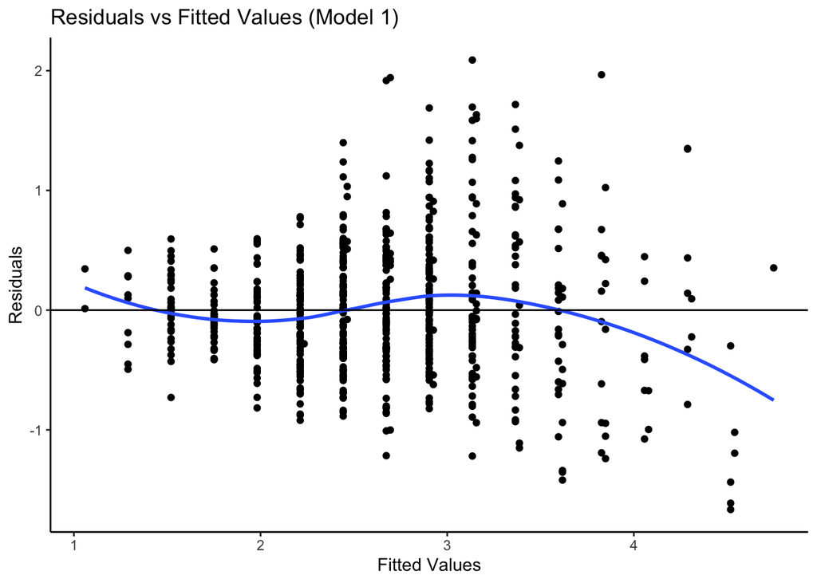

```r
# residuals vs fitted
augment(mod1) %>%
  ggplot(aes(y = .resid, x = .fitted)) +
  geom_point() +
  geom_smooth(se = FALSE) +
  geom_hline(yintercept = 0) +
  labs(x = 'Fitted Values', y = 'Residuals', title = 'Residuals vs Fitted Values (Model 1)') +
  theme_classic()
```

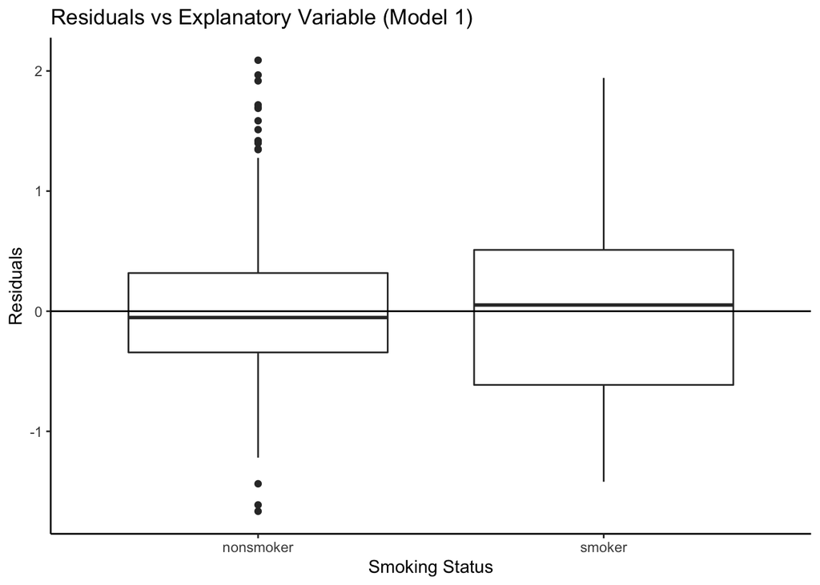

```r
# residuals vs smoke
augment(mod1) %>%
  ggplot(aes(y = .resid, x = smoke)) +
  geom_boxplot() +
  geom_smooth(se = FALSE) +
  geom_hline(yintercept = 0) +
  labs(x = 'Smoking Status', y = 'Residuals', title = 'Residuals vs Explanatory Variable (Model 1)') +
  theme_classic()
```

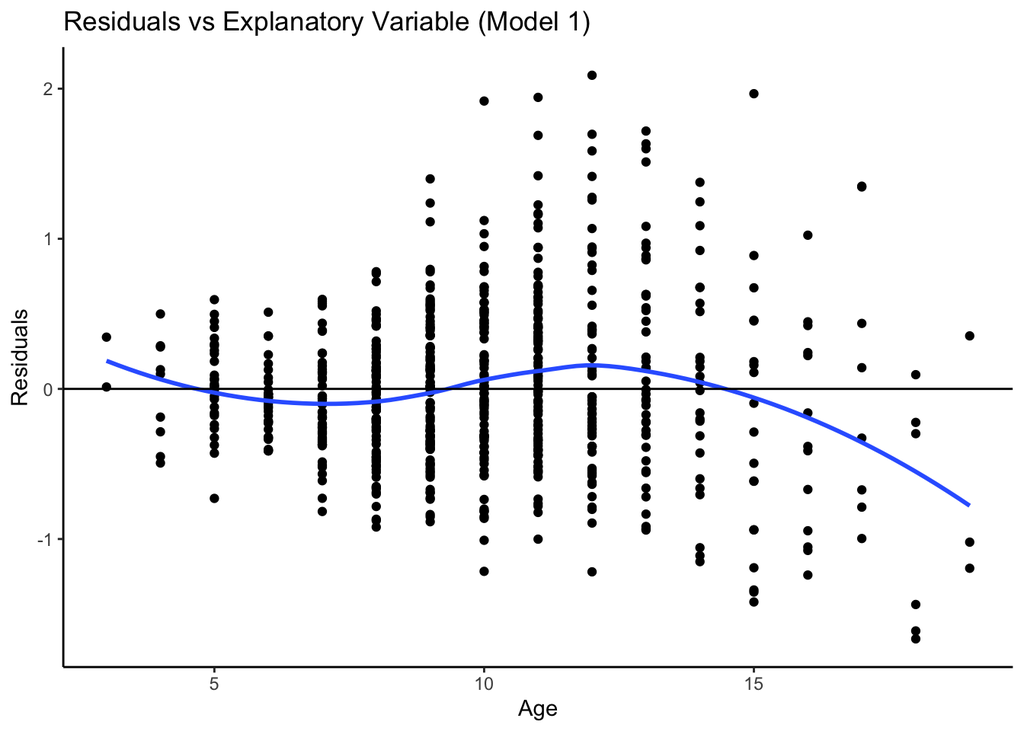

```r
# residuals vs age
augment(mod1) %>%
  ggplot(aes(y = .resid, x = age)) +
  geom_point() +
  geom_smooth(se = FALSE) +
  geom_hline(yintercept = 0) +
  labs(x = 'Age', y = 'Residuals', title = 'Residuals vs Explanatory Variable (Model 1)') +
  theme_classic()
```

What do you notice about these residual plots? Is there any pattern (i.e., is our model systematically under- or over-predicting for certain people)? Is there equal spread of residuals across fitted values and explanatory variables? What does all of this suggest about our model?

> I notice a trend that our model tends to *over-predict* (has negative residuals) for children with large fitted values (i.e., high values of predicted FEV) and children who are older (age > 15 or so).

> I don’t notice a particularly strong pattern with smoking: the median residual is slightly below zero for nonsmokers and slightly above zero for smokers, but both medians are quite close to zero. This suggest to me that there isn’t any tendency for our model to systematically over- or under-estimating FEV for either of these groups.

> The spread of the residuals seems like it could perhaps be increasing slightly as fitted values and ages increase (i.e., we see a bit of a fanning out pattern). The spread of the residuals is also a bit wider for smokers than it is for nonsmokers. Having a wider spread of our residuals suggests that more of our predictions are farther “off” (residuals far from zero, in either direction) for kids that are older, have higher predicted FEV, and/or smoke — our model isn’t as consistently good at predicting for these kids.

## Linear Regression - Evaluation - Model Quality Metrics

Calculate the R-squared and residual standard error for both models.

```r
# metrics for mod1
glance(mod1)
```

```
## # A tibble: 1 × 12
##   r.squared adj.r.squared sigma statistic   p.value    df logLik   AIC   BIC
##       <dbl>         <dbl> <dbl>     <dbl>     <dbl> <dbl>  <dbl> <dbl> <dbl>
## 1     0.577         0.575 0.565      443. 3.25e-122     2  -553. 1114. 1132.
## # … with 3 more variables: deviance <dbl>, df.residual <int>, nobs <int>
```

```r
# metrics for mod2
glance(mod2)
```

```
## # A tibble: 1 × 12
##   r.squared adj.r.squared sigma statistic   p.value    df logLik   AIC   BIC
##       <dbl>         <dbl> <dbl>     <dbl>     <dbl> <dbl>  <dbl> <dbl> <dbl>
## 1     0.594         0.592 0.554      317. 8.66e-127     3  -539. 1089. 1111.
## # … with 3 more variables: deviance <dbl>, df.residual <int>, nobs <int>
```

Which model has a better R-squared? Which model has a better residual standard error?

> We want R-squared to be high (closer to 1) and residual standard error to be low (closer to 0). It looks like `mod2` is best according to both of these metrics.

Write down an interpretation of the R-squared, in the context of the data, for whichever model you decided was best.

> Suppose we said `mod2` was best.

> The R-squared of 0.594 tells us that this model explains 59.4% of the variation in FEV.

> Note: adjusted R-squared does not have this same contextually-meaningful interpretation, so make sure you are interpreting R-squared rather than adjusted R-squared.

Write down an interpretation fo the residual standard error, in the context of the data, for whichever model you decided was best.

> The residual standard error of 0.554 gives us a sense of the “typical” size of our residuals (i.e., how far off do our predictions tend to be?). The residual standard error is the standard deviation of our residuals. It turns out that the mean of our residuals will always be zero. So, our residual standard error gives us a sense of how tightly concentrated all of our residuals are around zero, which in turn tells us how tightly concentrated our predictions are around the true values. Ideally, we want to see a small value here. There is a useful rule of thumb that tells us that, if our data are normally distributed, 95% of observations will fall within 2 standard deviations of the mean. Applying this rule to our residual standard error, we can say that our model predicts FEV for most kids within 1.108 liters per second. Considering that FEV of kids in this dataset ranges from about 1 up to 6, does being off by 1.1 liters/second seem like a lot?

## Linear Regression - Model Creation

Based on your work in Activity 18, what did you decide to use as your final model to answer the research question: *what is the impact of smoking on lung function in children?* Write down the model equation, using correct notation, below.

> There is more than one correct answer here! Different groups may have arrived at different final models depending on their background knowledge on this topic, their opinion about the trade-offs between complexity of the model and ease of interepretation, etc.

> At minimum, your model should have FEV as the outcome and smoking status as one of the explanatory variables. Without this, our model will not address our research question. Notation for this simple linear regression model would look like this:

$$E[FEV | smoke] = \beta_0 + \beta_1 smokesmoker$$

> However, we almost certainly need to include height and/or age in our model as well. As we’ve discussed in class, we have reason to believe that both age and height are causally associated with FEV among children: older kids will have more developed lungs (and be taller) and thus have better lung function, and taller kids will have larger lungs and thus have better lung function. We also have reason to believe that age would be associated with smoking in our sample, both based on scientific context (older kids are more likely to smoke, and after you turn 18 smoking is legal in many places) and our investigation of these data (we have in fact confirmed that kids who smoke tend to be older than those who don’t). Similarly, we might also expect that kids who smoke tend to be taller in this sample (because they are older). Finally, we know that smoking does not *cause* changes in age or height. So it seems reasonable that height and/or FEV could be confounding variables! Notation for a multiple linear regression model that adjusts for one or both of these variables as potential confounders would look like this:

$$\text{Just age: }E[FEV | smoke, age] = \beta_0 + \beta_1 smokesmoker + \beta_2 age$$

$$\text{Just height: }E[FEV | smoke, height] = \beta_0 + \beta_1 smokesmoker + \beta_2 height$$

$$\text{Both age and height: }E[FEV | smoke, age, height] = \beta_0 + \beta_1 smokesmoker + \beta_2 age + \beta_3 height$$

> As we’ve discussed in class, it also seems plausible that age could be an effect modifier here. The effect of smoking on lung function might differ depending on how old you are, and vice versa, the effect of age on lung function might differ depending on whether or not you smoke. Adjusting for age as an effect modifier, our model would need to include an interaction term as well:

$$\text{Age as an effect modifier: }E[FEV | smoke, age] = \beta_0 + \beta_1 smokesmoker + \beta_2 age + \beta_3 (smokesmoker * age)$$

> If you thought that any other variables might be an effect modifier, you would want to include them in your model in this way: both with a main effect for that variable (e.g., $\beta_2 age$) and with the interaction between that variable and smoking (e.g., $\beta_3 (smokesmoker*age)$). If you thought that any other variables were a confounder (associated with both FEV and smoking) or precision variable (associated with FEV but not smoking), then you would include them in your model using just a main effect, no interaction. Any variables that you identified as a collider, mediator, or irrelevant should be left out of the model.

> Another consideration in choosing which variables to include in a model is redundancy/multicollinearity. If there are two variables in our model that capture very similar information this can be *redundant* and actually pose problems for statistical inference. If this is the case, choose just one of these variables to include in your model.

Explain/justify your choice of model. Make sure to explain why you decided to include (or exclude) each variable in the way that you did.

> Similar to my answers above, your explanation/justification for your choice of model should clearly explain why you included each variable that you did in your model. Is it necessary for answering your research question? Is it a potential confounder, effect modifier, or precision variable? Your justification should match the model you fit. If you described a variable as a potential effect modifier, then your model should include an interaction term. Otherwise, it should not.

> Since there are not many variables in this dataset, it is also useful to discuss why you did **not** include a variable in your model. Is it a potential collider or mediator? Is it redundant with another variable(s) that you *did* include in the model? Did you feel that the variable was entirely unrelated to our outcome, FEV?

# Part 2. Project Data

Answer the following questions about your chosen project dataset. Use the same dataset you used last week (unless you have approval from Kelsey to change datasets).

## Load and Prep Data in R

Use the code chunk provided below to read your chosen data set into R. Add `messsage = FALSE` to the start of your code chunk to hide the messages that print out when you read in this dataset.

> If you’re using the NHANES data for your project, your code should look something like this:

```r
# load package first, or put this up in Part 0
library(NHANES)

# then read in dataset
data(NHANES)
```

> Otherwise, you’re likely using the `read_csv` function to read in your data from a CSV file. Since we already loaded the `readr` package in an earlier code chunk, we don’t need to do it again here:

```r
# read in dataset
project <- read_csv('projectdata.csv')
```

> Note: in the example above, my code reads in a dataset called “projectdata.csv” and saves it as an object called `project`. You can give your data whatever* name you like! Just make sure to use the same name throughout. For example, if you named your data `kiva` (`kiva <- read_csv('...')`) then run the `ggplot` function on “kiva” as well (`kiva %>% ggplot(...)` in the next question).

> *there are a few rules to naming objects in R. Names can’t start with a number, can’t include some special characters like @, /, &, or spaces, and shouldn’t be the name of something that already exists (e.g., don’t name your data “read_csv”). I recommend using a name that’s short and informative, so it’s easy to type and easy to remember what you called it.

> Another note: the `read_csv()` function prints out quite a bit of information when it loads in the dataset. You can hide these messages by adding `message = FALSE` to the first line of your code chunk. It should like something like this: `{r name-of-chunk, message = FALSE}`.

Use the next code chunk to perform any data cleaning or other preparation that you need (e.g., filtering missing values, creating or modifying variables) to fit your linear regression model, below.

> Here are two examples of what the code might look like to create a new variable (using `mutate`) or filter out outliers or missing values. Your steps here, of course, will be unique to your dataset and research question. Stop by office hours for help with brainstorming and implementing any data cleaning steps that are necessary for your project.

```r
## example: make categorical variable from a quantitative one
## for more examples, see Crowd-Sourced R Help File on Moodle
data <- data %>%
  mutate(Xcat = cut(Xquant, 4))

## example: filter cases
data.filtered <- data %>%
  filter(Y <= 100)  %>% # keep y values less than or equal to 100
  filter(!is.na(x))  # keep cases that are not missing (NA) for variable x
```

## Research Question

For your chosen data set, write down the research question that you will be investigating that involves a *quantitative* outcome variable and one or two explanatory variables. Make sure to incorporate any feedback/suggestions that you got about your research question on previous assignments.

> Research Question #1: There are no “correct” answers to this question, as long as you wrote down a research question that could reasonably be answered using your chosen dataset (i.e., there are variables in the dataset that we could use to investigate these questions), and the outcome variable is *quantitative* (numerical values, with units). I encourage you to limit the scope of your research question by focusing on the relationship between two, or at most three, variables.

> Remember that you’ll need to provide motivation/justification for studying this question in the *Introduction* section of your final report.

## Model Creation

Write out the notation for a multiple linear regression model that addresses your research question and appropriately adjusts for any confounding variables, precision variables, and/or effect modifiers

> For the **model equation**, the names of your variables should be input in place of $Y, X_1, X_2, ...$ in the equation below. For your categorical explanatory variable(s), there should be an indicator variable (and beta) for all but one of the categories. If you decided to include an interaction in your model, make sure you have both the main effects (e.g., $\beta_1 X_1, \beta_2 X_2$ as well as the interaction $\beta_3 X_1 X_2$).

$$E[Y | X_1, X_2] = \beta_0 + \beta_1 X_1 + \beta_2 X_2$$

> Try to write your model equation in a way that will be accesible to a general audience. Replace dataset specific jargon/variable names with new names that could be immediately understood by someone who is not familar with your dataset.

> Check your formatting to make sure that subscripts, etc. are appearing correctly. Also check your Knitted document to make sure that the entire equation is visible on the page. If part of the equation is trailing off the page, try adding a line break:

$$E[Y | XCat, XQuant] = \beta_0 + \beta_1 XCat1 + \beta_2XCat2 + \beta_3XCat3 + \beta_4XCat4 \\ + \beta_5XCat5 + \beta_6 XCat6 + \beta_7 XQuant$$

Then, justify this choice of model:

> As above, your justification should clearly explain why each variable was included in your model (confounder? precision variable? effect modifier? necessary for answering the research question?) in the way it was included (with or without an interaction). If you performed any transformations on your variables (e.g., making a quantitative variable categorical, rescaling or centering a quantitative variable), make sure that is explained as well.

## Fit Model

Fit that model to the data using the `lm` function, and print out the coefficient estimates:

> To fit the model, the names of your variables should be input in for Y, X1, X2, … in code similar to the code below. Add in `X1:X2` as well if you want to fit an interaction model.

> If you filtered your data earlier (to remove outliers, missing values, etc.), make sure you are using the filtered version of your dataset when fitting this model.

```r
# fit and save model (using filtered data, if needed)
mod <- lm(Y ~ X1 + X2, data = data.filtered)

# print coefficient estimates: option 1
coef(mod)

# print coefficient estimates: option 2
tidy(mod)
```

## Interpret

Using full, good sentences, write a sentence that interprets the value of the coefficient(s) of interest (i.e., the coefficient(s) that most directly address your research question). Double-check the [Final Grading Rubric](https://docs.google.com/spreadsheets/d/14PFacGUuS5tiQuTdpbL155L8YTQLWnXg9Tb9qt-vYVg/edit#gid=0) to make sure you are meeting all expectations for interpretations.

> You do not need to interpret *all* of the coefficients in your model. Focus only on the coefficient (or coefficients) that are most directly relevant to your research question. For example, this will typically mean that you will not be interpreting your intercept. Instead, focus on the slope(s) of the explanatory variable(s) at the center of your research question.

> All interpretations include the estimate itself, rounded to a reasonable number of digits. Make sure to include units, clearly specify which reference category we are comparing to (in the case of categorical predictors), describe the variables in an accessible way instead of using “x” and “y” or the variable name from the dataset, talk about averages across groups rather than trends/trajectories for individual cases, avoid causal language if data come from an observational study, and take into account (e.g., “adjust for”) all other variables. If your model includes an interaction term, remember that we “take into account other variables” by setting them equal to zero.

> See the Project Rubric for a full list of interpretation expectations.

## Evaluate

Write R code to evaluate your model: create residual plot(s) and calculate R-squared and residual standard error.

> At minimum, you should have created a residuals vs fitted values plot for each of your models. It is also often useful to plot residuals versus each of the explanatory variables in your model. This helps us check if there are any patterns in the residuals (and the performance of our model) across our different explanatory variables.

> In terms of model quality metrics, we’ll want to look at R-squared and residual standard error. We can use `glance` to get both of those.

```r
# residuals vs fitted
augment(mod) %>%
  ggplot(aes(x = .fitted, y = .resid)) +
  geom_point() +
  geom_hline(yintercept = 0)+
  geom_smooth(se=FALSE)

# residuals vs quantitative X1
augment(mod) %>%
  ggplot(aes(x = X1, y = .resid)) +
  geom_point() +
  geom_hline(yintercept = 0)+
  geom_smooth(se=FALSE)

# residuals vs categorical X2
augment(mod) %>%
  ggplot(aes(x = X2, y = .resid)) +
  geom_boxplot() +
  geom_hline(yintercept = 0)

# model quality metrics
glance(mod)
```

Based on the plot(s) and model quality metrics you generated above, comment on whether the model satisfies all linear model conditions (straight enough relationships between quantitative variables/no pattern in residual plots, equal spread in residuals, no extreme outliers), as well as it’s “goodness” ($R^2$, residual standard error). Describe what you learn from each of these tools *in context*.

> Straight enough/no pattern in residual plots: comment on whether there is a pattern in residuals (based on mean of residuals in residual vs fitted/quantitative X plots, and/or centers of boxplots in residual vs categorical X plots); is the model systematically over- (negative residuals) or under-predicting (positive residuals) for certain cases?

> Equal spread: is there equal spread in the outcome or residuals for all values of X? or is there some sort of fanning out pattern?

> Outliers: are there any extreme outliers that may influence the linear regression model?

> $R^2$: eport and interpret R-squared (% of variation in Y that can be explained by the model). **Note:** adjusted R-squared does not have the same nice interpretation that ordinary R-squared does. That is, while R-squared tells us the % of variation in Y that can be explained by the model, adjusted R-squared is not quite interpretable the same way (but is very close). I would recommend discussing “ordinary” R-squared in this context for it’s interpretability.

> Residual standard error: report and interpret RSE (our model can predict the outcome within 2*RSE units; the RSE is (roughly) the average magnitude of the residuals/prediction errors)

> Takeaway message: does the model meet all conditions (straight enough, equal spread, no extreme outliers) or does it fail to meet one or more of these conditions? based on the R-squared (which we want to be large) and the residual standard error (which we want to be small), is this a good model?

## Conclusions

Provide a brief discussion of the conclusions and limitations of your preferred model. What do you learn from your model about your research question? What are the limitations/downsides of this model? Are there any changes you’d like to explore in future weeks?

> Takeaway message: what do you learn from your model about your research question?

> Limitations/downsides of model: what are this model’s limitations? does it fail to meet one or more of the linear model conditions? is the R-squared lower than you would like? is the residual standard error higher than you would like? is it possible that your two explanatory variables are redundant? are there any other potential confounding variables, precision variables, or effect modifiers that you have not included in this model?

> Potential changes/improvements to model: what changes might you consider making to your model in future weeks to address some of the limitations you outlined above?

# Part 3. Knit

Once you’ve answered all the questions above, you’ll need to `Knit` this document and then save that knitted document as a PDF. See the assignment *Instructions* at the top of this document and on Moodle for more details.